# Heart Rate Lab

Alberto Barradas

## Overview

- Introduction
- HRV Measurements
- The HeartRateLab
  - Preprocessing
  - Feature Exploration
  - Dynamic Systems Modeling
  - Statistical Modeling
  - Deep Learning
  - Visualization
- Problem Solving with the HeartRateLab
- What do we do with the HeartRateLab?
  - Arousal and Relaxation
  - Cognitive Mental Workload
  - Attention and Dual-Tasking
  - Attentional Networks
  - *Facial Expression Observation
  - *Ocular Rivalry and Concious Perception
  - *Cognitive Flexibility
  - Heart Rate Variability Biofeedback
  - Mindfulness and Contemplative Practices
  - Neurodiversity, ADHD, and Autism
- Future Work

## Slides with code

Slides in this presentation are written in [Quarto](https://quarto.org/), a literate programming tool that allows you to write documents with embedded code. The code is executed and the results are included in the final document. This allows for reproducible research and easy sharing of results.

```julia
using Pkg;
# Pkg.add("HypothesisTests")
Pkg.activate("/home/beto/.julia/dev/HeartRateLab/docs/slides")
# Pkg.add(url="https://github.com/abcsds/LSL.jl")
# Pkg.add(url="https://github.com/abcsds/DFA.jl")
# Pkg.add(path="/home/beto/.julia/dev/HeartRateLab")
# Pkg.add(["StatsBase", "GLMakie", "SequentialSamplingModels"])
# Pkg.instantiate();
# Pkg.precompile();

using StatsBase
using GLMakie
using DFA: DFA
using HeartRateLab: HeartRateLab
```

## Introduction

- Cardiac Cycle and Heart Rate
- Heart Rate Variability (HRV)
- Factors that influence HRV
- Correlations found in HRV studies
- Applications of HRV in research and practice
- Existing HRV analysis tools
  - [PyCardio](https://javierfm27.github.io/)
  - [PyHRV](https://github.com/PGomes92/pyhrv)
  - [PyNeuroKit2](https://github.com/neuropsychology/NeuroKit/tree/master/neurokit2/hrv)
  - [HeartRateVariablitiy.jl](https://github.com/LiScI-Lab/HeartRateVariability.jl)
  - [Kubios](https://www.kubios.com/)

## Cardiac Cycle and Heart Rate

[figure not shown]

By Guido4 - Own work http://www.hegasy.de/, CC BY-SA 4.0, https://commons.wikimedia.org/w/index.php?curid=63765394

[figure not shown]

By DrJanaOfficial - Own work: Cardiac Cycle, Wiggers diagram derived from User:Xavax, CC BY-SA 4.0, https://commons.wikimedia.org/w/index.php?curid=54393545

[figure not shown]

Cardiac Cycle

## Sinoatrial and Atrioventricular Nodes

[figure not shown]

By J. Heuser - self made, based upon Image:Heart anterior view coronal section.jpg by Patrick J. Lynch (Patrick J. Lynch; illustrator; C. Carl Jaffe; MD; cardiologist Yale University Center for Advanced Instructional Media ), CC BY 2.5, https://commons.wikimedia.org/w/index.php?curid=1686121

## Heart Rate Variability (HRV)

[figure not shown]

By YitzhakNat - Own work + ECG wave from, CC BY-SA 4.0, https://commons.wikimedia.org/w/index.php?curid=121207798

# Interbeat Intervals

```julia
# infile = "/home/beto/.julia/dev/HeartRateLab/test/testdata/example.txt"
# infile = "/home/beto/.julia/dev/HeartRateLab/test/testdata/e1304.txt"
infile = "/home/beto/.julia/dev/HeartRateLab/docs/slides/example.xdf"
data = Float64.(HeartRateLab.read_xdf(infile))

println("Data loaded from: ", infile)
println("Data length: $(length(data)) heartbeats")
println("Type of data: ", typeof(data))
```

```
Data loaded from: /home/beto/.julia/dev/HeartRateLab/docs/slides/example.xdf
Data length: 341 heartbeats
Type of data: Vector{Float64}
```

[figure not shown]

Generic Heart Rate Monitor

[figure not shown]

Polar H10

## HRV Measurements

- Time and Statistical Domain
- Frequency Domain
- Geometric Domain
- Nonlinear Domain

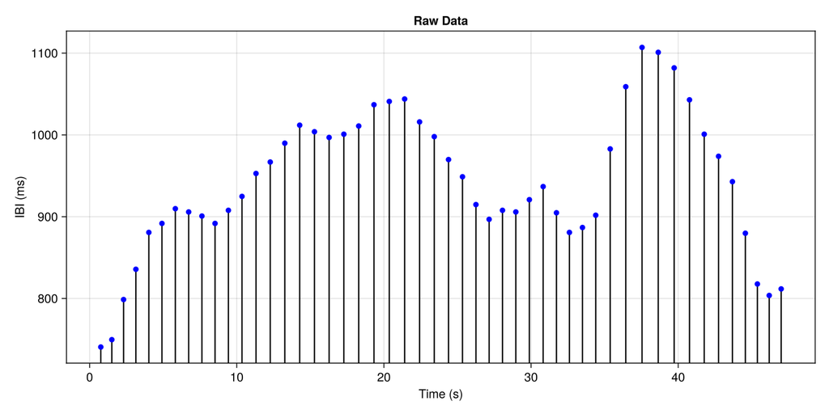

```julia
f = Figure(size=(1200, 600));
ax = Axis(f[1, 1],
    title="Raw Data",
    xlabel="Time (s)",
    ylabel="IBI (ms)")
n = data[1:50]
t = Observable(cumsum(n) ./ 1000) # to seconds
# x = Observable(60000 ./ n) # to bpm
x = Observable(n)
stem!(ax, t, x, color=:blue)
ylims!(ax, (minimum(n) - 20, maximum(n) + 20))
f
```

## IBIS are inversely proportional to Heart Rate

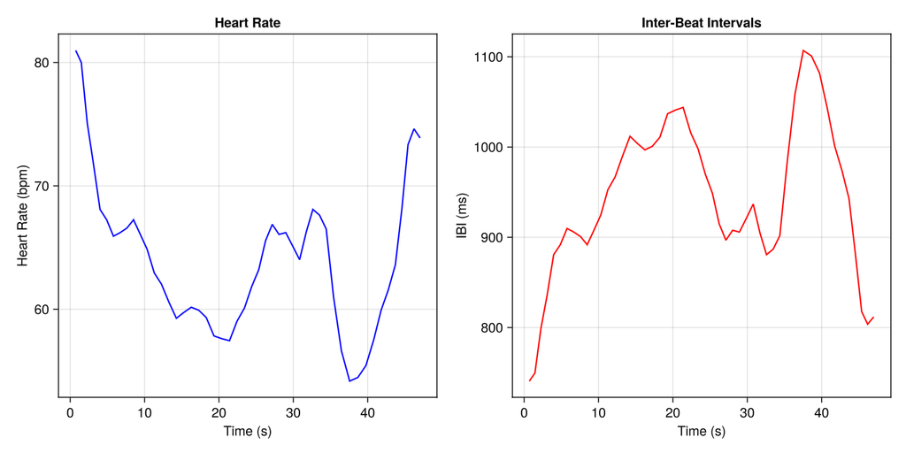

```julia
f = Figure(size=(1400, 600));
ax1 = Axis(f[1, 1],
    title="Heart Rate",
    xlabel="Time (s)",
    ylabel="Heart Rate (bpm)")
n = data[1:50]
t = Observable(cumsum(n) ./ 1000) # to seconds
x = Observable(60000 ./ n) # to bpm
lines!(ax1, t, x, color=:blue, label="Heart Rate")
ax2 = Axis(f[1, 2],
    title="Inter-Beat Intervals",
    xlabel="Time (s)",
    ylabel="IBI (ms)")
lines!(ax2, t, n, color=:red, label="IBI")
f
```

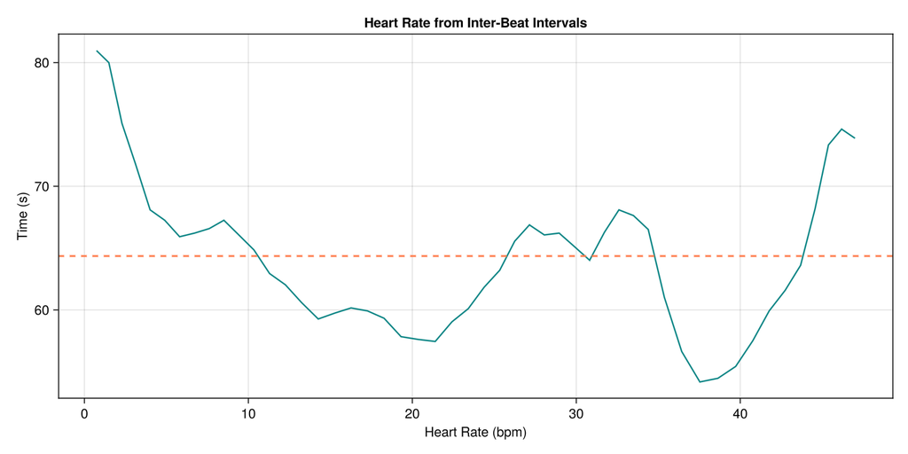

```julia
f = Figure(size=(1600, 600));
ax = Axis(f[1, 1],
    title="Heart Rate from Inter-Beat Intervals",
    xlabel="Heart Rate (bpm)",
    ylabel="Time (s)")
n = data[1:50]
t = Observable(cumsum(n) ./ 1000) # to seconds
x = Observable(60000 ./ n) # to bpm
lines!(ax, t, x, color=:teal, label="Continuous Heart Rate")
hlines!(ax, mean(x[]), label="Mean Heart Rate", linestyle=:dash, color=:coral, linewidth=2)

f
```

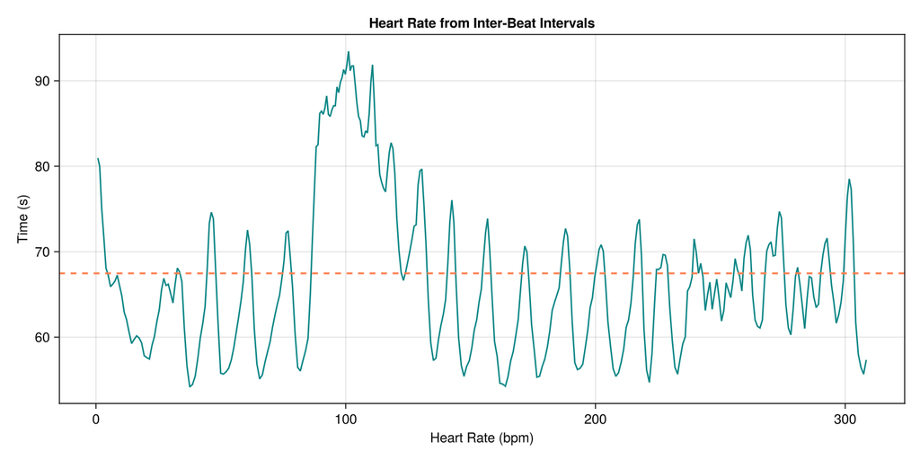

```julia
f = Figure(size=(1600, 600));
ax = Axis(f[1, 1],
    title="Heart Rate from Inter-Beat Intervals",
    xlabel="Heart Rate (bpm)",
    ylabel="Time (s)")
n = data
t = Observable(cumsum(n) ./ 1000) # to seconds
x = Observable(60000 ./ n) # to bpm
lines!(ax, t, x, color=:teal, label="Continuous Heart Rate")
hlines!(ax, mean(x[]), label="Mean Heart Rate", linestyle=:dash, color=:coral, linewidth=2)

f
```

## Time Domain

- Mean
- Standard Deviation (SDNN)
- Median
- Extrema and Range
- BPM representations
- SDSD
- RMSSD
- SDANN
- PNN50, PNN20 and percentages
- CVSD
- rRR

## An empirical random variable

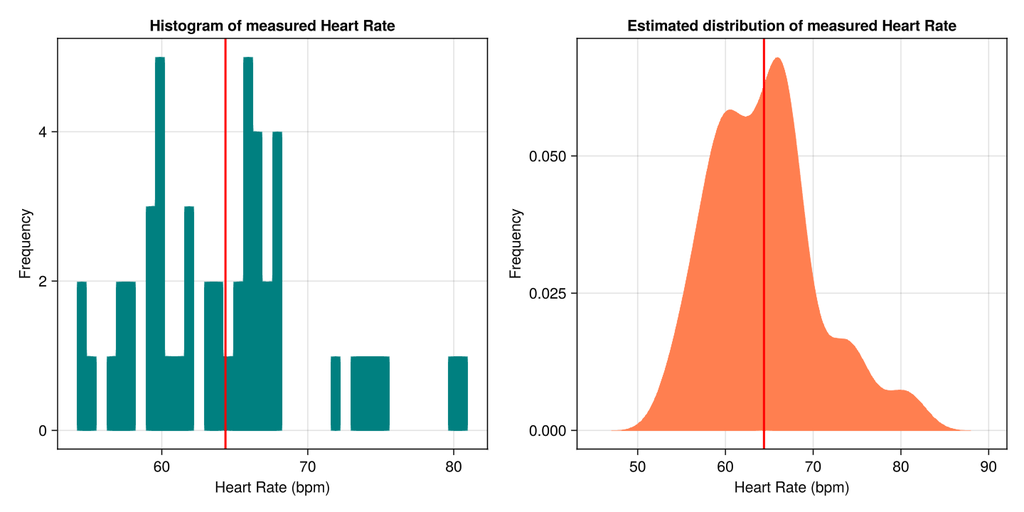

```julia
# A histogram of the first 50 heartbeats
f = Figure(size=(1400, 600));
ax1 = Axis(f[1, 1],
    title="Histogram of measured Heart Rate",
    xlabel="Heart Rate (bpm)",
    ylabel="Frequency")
n = data[1:50]
t = Observable(cumsum(n) ./ 1000) # to seconds
x = Observable(60000 ./ n) # to bpm
hist!(ax1, x, color=:teal, bins=40)
vlines!(ax1, mean(x[]), color=:red, linewidth=2, label="Mean")

ax2 = Axis(f[1, 2],
    title="Estimated distribution of measured Heart Rate",
    xlabel="Heart Rate (bpm)",
    ylabel="Frequency")
# Makie.boxplot!(ax2, x, color=:teal, label="Heart Rate Boxplot"; orientation=:horizontal)
density!(ax2, x, color=:coral, label="Distribution Density")
vlines!(ax2, mean(x[]), color=:red, linewidth=2, label="Mean")

f
```

## Numeric Derivative

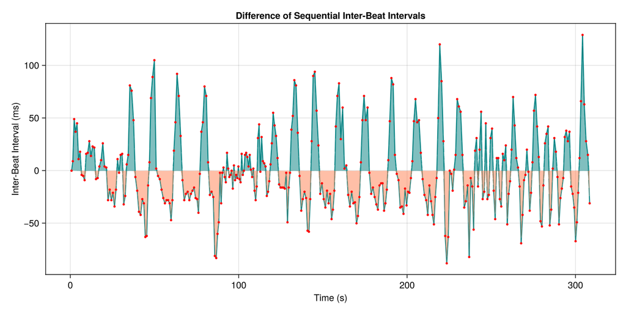

```julia
f = Figure(size=(1200, 600));
ax = Axis(f[1, 1],
    title="Difference of Sequential Inter-Beat Intervals",
    xlabel="Time (s)",
    ylabel="Inter-Beat Interval (ms)")
n = data[1:end]
t = Observable(cumsum(n) ./ 1000) # to seconds
x = Observable([0; diff(n)])
x_above_zero = Observable(clamp.(x[], 0, Inf))
x_below_zero = Observable(clamp.(x[], -Inf, 0))
zero_line = Observable(zeros(length(x[])))
lines!(ax, t, x, color=:teal)
# Band above zero
# band(x, ylower, yupper; kwargs...)
band!(ax, t, zero_line, x_above_zero,
    color=:teal, alpha=0.5)
band!(ax, t, zero_line, x_below_zero,
    color=:coral, alpha=0.5)
scatter!(ax, t, x, color=:red, markersize=5)
f
```

## RMSSD

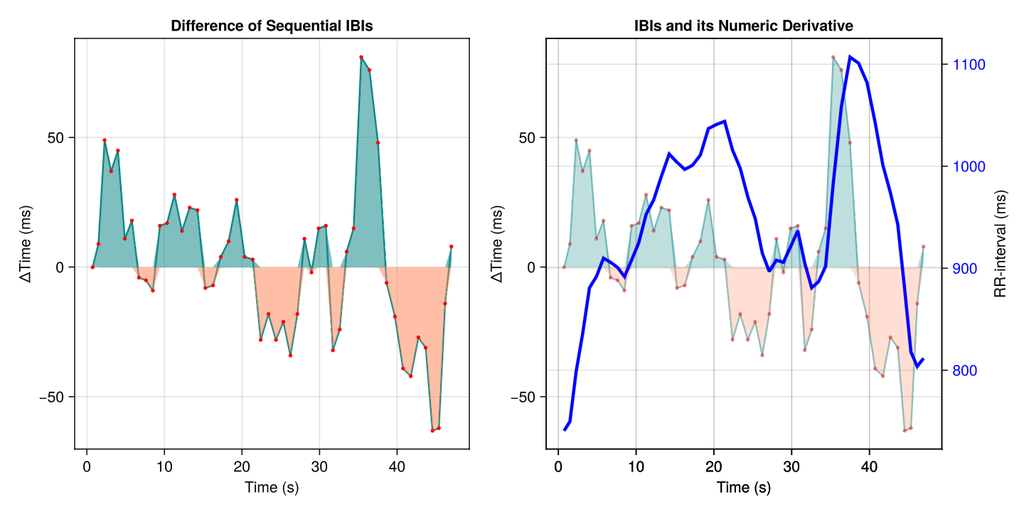

```julia
n = data[1:50]
t = Observable(cumsum(n) ./ 1000) # to seconds
x = Observable([0; diff(n)])
x_above_zero = Observable(clamp.(x[], 0, Inf))
x_below_zero = Observable(clamp.(x[], -Inf, 0))
zero_line = Observable(zeros(length(x[])))
f = Figure(size=(1600, 600));
ax1 = Axis(f[1, 1],
    title="Difference of Sequential IBIs",
    xlabel="Time (s)",
    ylabel="ΔTime (ms)")
lines!(ax1, t, x, color=:teal, label="ΔRR[n, n+1]")
# Band above zero
# band(x, ylower, yupper; kwargs...)
band!(ax1, t, zero_line, x_above_zero,
    color=:teal, alpha=0.5)
band!(ax1, t, zero_line, x_below_zero,
    color=:coral, alpha=0.5)
scatter!(ax1, t, x, color=:red, markersize=5)

ax2 = Axis(f[1, 2],
    title="IBIs and its Numeric Derivative",
    xlabel="Time (s)",
    ylabel="ΔTime (ms)")
lines!(ax2, t, x, color=:teal, alpha=0.5)
band!(ax2, t, zero_line, x_above_zero, color=:teal, alpha=0.25)
band!(ax2, t, zero_line, x_below_zero, color=:coral, alpha=0.25)
scatter!(ax2, t, x, color=:red, markersize=5, alpha=0.5)

ax3 = Axis(f[1, 2],
    xlabel="Time (s)",
    ylabel="RR-interval (ms)",
    yticklabelcolor=:blue,
    yaxisposition=:right
    )
lines!(ax3, t, n, color=:blue, linewidth=3, label="Detrended RR-interval signal")

f
```

```julia
println("SDNN: ", round(StatsBase.std(n), digits=2))
println("RMSSD: ", round(StatsBase.std(x[]), digits=2))
```

```
SDNN: 85.4
RMSSD: 30.03
```

## Frequency Domain

- Power Spectral Density (PSD) over four frequency bands:
  - High Frequency (HF): 9-24 BPM (0.15-0.4 Hz)
  - Low Frequency (LF): 2.4-9 BPM (0.04-0.15 Hz)
  - Very Low Frequency (VLF): .18-2.4 BPM (0.003-0.04 Hz)
  - Ultra Low Frequency (ULF): < .18 BPM (< 0.003 Hz)
- Absolute and relative power
- Peak frequencies
- Proportions and ratios (LF/HF, VLF/LF, etc.)

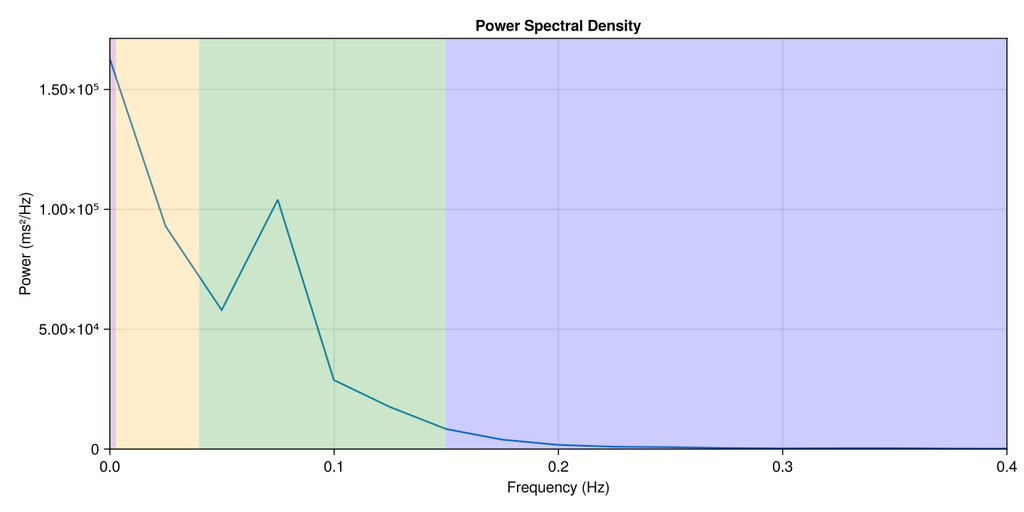

## Geometric Domain

- Poincaré Plot
  - SD1: Short-term variability
  - SD2: Long-term variability
  - SD1/SD2 ratio, area
  - cvi
  - ccsi
- Histogram Based:
  - Triangular Index
  - Triangular Interpolation of NN intervals (TINN)

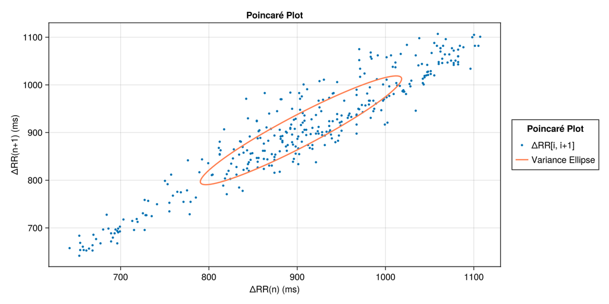

```julia
function getellipsepoints(cx, cy, rx, ry, θ)
    t = range(0, 2*pi, length=100)
    ellipse_x_r = @. rx * cos(t)
    ellipse_y_r = @. ry * sin(t)
    R = [cos(θ) sin(θ); -sin(θ) cos(θ)]
    r_ellipse = [ellipse_x_r ellipse_y_r] * R
    x = @. cx + r_ellipse[:,1]
    y = @. cy + r_ellipse[:,2]
    (x,y)
end
x = [data[i] for i in 1:length(data)-1]
y = [data[i+1] for i in 1:length(data)-1]
sd1 = sqrt(StatsBase.var((x - y) / sqrt(2)))
sd2 = sqrt(StatsBase.var((x + y) / sqrt(2)))
f = Figure(size=(1200, 600));
ax = Axis(f[1, 1],
    title="Poincaré Plot",
    xlabel="ΔRR(n) (ms)",
    ylabel="ΔRR(n+1) (ms)")
scatter!(ax, x, y, markersize=5, label="ΔRR[i, i+1]")
cx = mean(x)
cy = mean(y)
ellipse_x, ellipse_y = getellipsepoints(cx, cy, sd2, sd1, π/4)
lines!(ax, ellipse_x, ellipse_y, linewidth=2, label="Variance Ellipse", color=:coral)
f[1,2] = Legend(f, ax, "Poincaré Plot",
    position=:bottomright,
    title="Poincaré Plot Legend",
    fontsize=10,
    bgcolor=:white,
    framecolor=:black)

f
```

## Nonlinear Domain

- Approximate Entropy (ApEn)
- Sample Entropy (SampEn)
- Hurst Exponent
- Renyi Entropy
- Detrended Fluctuation Analysis (α1, α2)

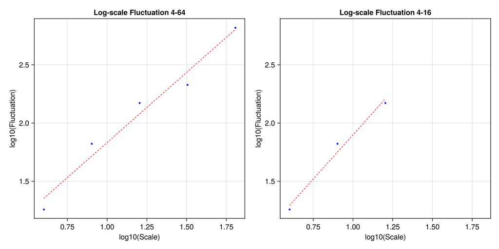

```julia
scales, fluc = DFA.dfa(data, boxmin=4, boxmax=64, boxratio=2, overlap=0.0)
log_scales1 = log10.(scales)
log_fluc1 = log10.(fluc)
f = Figure(size=(1200, 600));
ax1 = Axis(f[1, 1],
    title="Log-scale Fluctuation 4-64",
    xlabel="log10(Scale)",
    ylabel="log10(Fluctuation)",
)
scatter!(ax1, log_scales1, log_fluc1, color=:blue, markersize=5)
intercept1, α1 = DFA.polyfit(log_scales1, log_fluc1)
x = range(minimum(log_scales1), maximum(log_scales1), length=100)
y = intercept1 .+ α1 .* x
lines!(ax1, x, y, color=:red, linewidth=1, linestyle=:dash)
# f

scales, fluc = DFA.dfa(data, boxmin=4, boxmax=16, boxratio=2, overlap=0.0)
log_scales2 = log10.(scales)
log_fluc2 = log10.(fluc)
ax2 = Axis(f[1, 2],
    title="Log-scale Fluctuation 4-16",
    xlabel="log10(Scale)",
    ylabel="log10(Fluctuation)",
)
scatter!(ax2, log10.(scales), log10.(fluc), color=:blue, markersize=5)
intercept2, α2 = DFA.polyfit(log_scales2, log_fluc2)
x = range(minimum(log_scales2), maximum(log_scales2), length=100)
y = intercept2 .+ α2 .* x
lines!(ax2, x, y, color=:red, linewidth=1, linestyle=:dash)
linkxaxes!(ax1, ax2)
linkyaxes!(ax1, ax2)
f
```

[figure not shown]

## The HeartRateLab

[figure not shown]

The HeartRateLab (placeholder logo)

1×2 DataFrame

[output not shown]

## Preprocessing

- Input from TXT: EliteHRV, Kubios
- Input as WFDB: PhysioNet
- Input as XDF: sub ms precision, markers
- Live input from LSL:
  - Synchronized signals and data
  - Combine with myraid of other devices
- Replace Zeros
- Replace biological outliers (200 to 3000 ms) and breaks
- Replace statistical outliers (Z(0.025, 0.975))
- Ectopic beat detection:
  - ACAR Acar et al. (2000)
  - Karlsson Karlsson et al. (2012)
  - Malik Malik (1996)
  - Kamath Kamath and Fallen (1995)
  - Custom absolute threshold (0.2)
- Signal interpolation:
  - Constant
  - Linear
  - Quadratic
  - Cubic
- Windowed analysis:
  - Sliding window
  - Overlapping windows
  - Non-overlapping windows

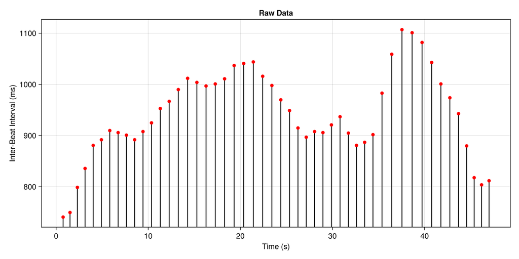

```julia
f = Figure(size=(800, 600));
ax = Axis(f[1, 1],
    title="Raw Data",
    xlabel="Time (s)",
    ylabel="Inter-Beat Interval (ms)",
    )
n = data[1:50]
x = Observable(n)
t = Observable(cumsum(n) ./ 1000) # to seconds
stem!(ax, t, x, color=:red)
ylims!(ax, (minimum(n) - 20, maximum(n) + 20))
f
```

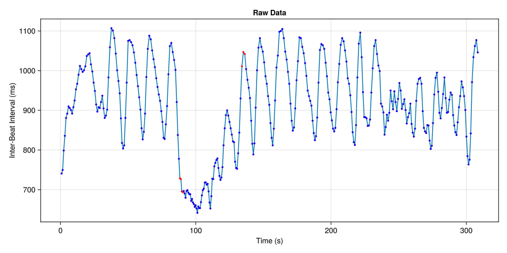

```julia
f = Figure(size=(800, 600));
ax = Axis(f[1, 1],
    title="Raw Data",
    xlabel="Time (s)",
    ylabel="Inter-Beat Interval (ms)")
n = data[1:end]
x = Observable(n)
t = Observable(cumsum(n) ./ 1000) # to seconds
lines!(ax, t, x)
scatter!(ax, t, x, color=:red, markersize=5)

# Detect outliers
# xn = HeartRateLab.replace_ectopic_beats(n, method=:karlsson)
xn = HeartRateLab.replace_ectopic_beats(n, method=:acar, threshold=0.20)
x = Observable(xn)
scatter!(ax, t, x, color=:blue, markersize=5, label="Ectopic Beats Removed")

f
```

## Feature Extraction

[output not shown]

[output cut: 65 more lines]

[output not shown]

<sup>1</sup>

[^1]: This diagram was created using [Mermaid](https://www.mermaidchart.com/app/projects/6610a32b-227b-43a9-b1fa-b89efed43c9a/diagrams/dcfcaeb2-4ede-4954-afd6-3518e25ddb14/version/v0.1/edit)

## Rolling Window Features

```
Extracted 29 windows with 2 features each.
```

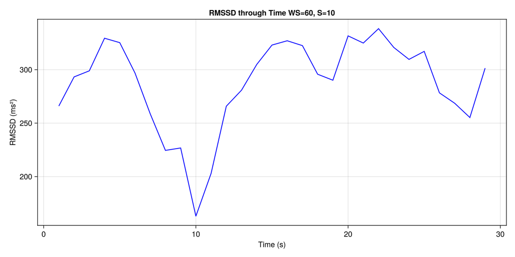

```julia
ds_windowed = HeartRateLab.Features.windowed_feature_set(
    data, features=["vlf", "rmssd"], window_size=60, stride=10
)

f = Figure(size=(1200, 600));
ax = Axis(f[1, 1],
    title="RMSSD through Time WS=60, S=10",
    xlabel="Time (s)",
    ylabel="RMSSD (ms²)")
x = ds_windowed.rmssd
t = 1:length(x)
lines!(ax, t, x, color=:blue)
f
```

## With different resolutions

```
Extracted 312 windows with 2 features each.
```

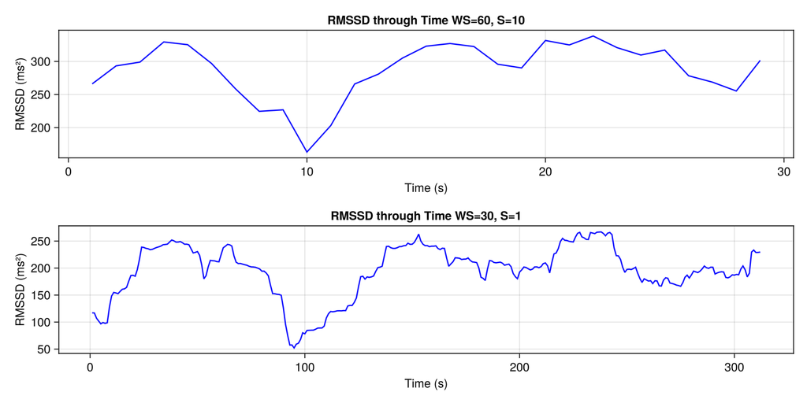

```julia
ds_windowed = HeartRateLab.Features.windowed_feature_set(
    data, features=["vlf", "rmssd"], window_size=30, stride=1
)

ax = Axis(f[2, 1],
    title="RMSSD through Time WS=30, S=1",
    xlabel="Time (s)",
    ylabel="RMSSD (ms²)")
x = ds_windowed.rmssd
t = 1:length(x)
lines!(ax, t, x, color=:blue)
f
```

```
Extracted 45 windows with 2 features each.
```

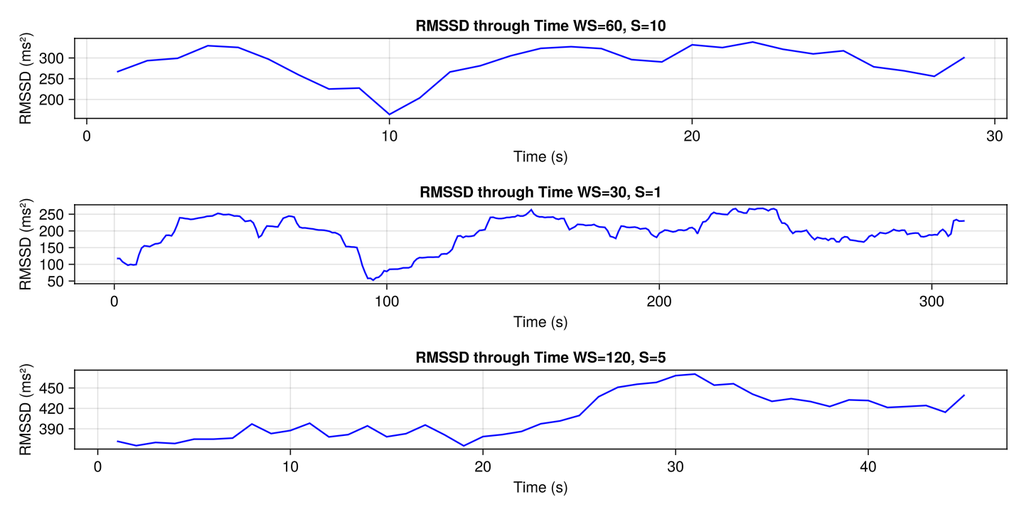

```julia
ds_windowed = HeartRateLab.Features.windowed_feature_set(
    data, features=["vlf", "rmssd"], window_size=120, stride=5
)

ax = Axis(f[3, 1],
    title="RMSSD through Time WS=120, S=5",
    xlabel="Time (s)",
    ylabel="RMSSD (ms²)")
x = ds_windowed.rmssd
t = 1:length(x)
lines!(ax, t, x, color=:blue)
f
```

## Windowed Frequency Analysis

```
Minimum size: 86.0
Minimum in X: 86
```

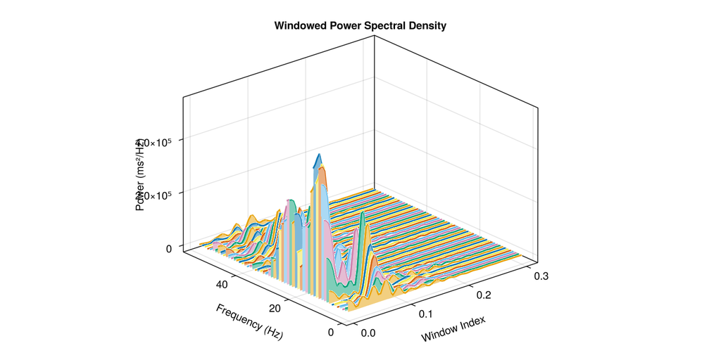

```julia
using HeartRateLab.Frequency: lomb_scargle
ds_windowed = HeartRateLab.windowed(data, window_size=60, stride=5)
freq = lomb_scargle(ds_windowed[1]).freq
y_values = 1:length(ds_windowed)
X = []
min_size = Inf
for i in 1:length(ds_windowed)
    w = ds_windowed[i]
    y = y_values[i]
    pgram = lomb_scargle(w)
    x = pgram.freq
    z = pgram.power
    push!(X, z)
    min_size = min(min_size, length(x))
end
# Crop every element to the minimum size
println("Minimum size: ", min_size)
println("Minimum in X: ", minimum([length(x) for x in X]))
for i in 1:length(X)
    X[i] = X[i][1:Int(min_size)]  # Ensure all have the same length
end
X = hcat(X...) # Windows by Frequency
y_values = 1:size(X, 2) # Window Index
freq = freq[1:Int(min_size)] # Crop frequency to the minimum size
f = Figure(size=(1600, 800));
ax = Axis3(f[1, 1],
    title="Windowed Power Spectral Density",
    xlabel="Window Index",
    ylabel="Frequency (Hz)",
    zlabel="Power (ms²/Hz)",
    # limits=((0, length(ds_windowed)), (0, 0.5), (0, nothing)),
)
for i in 1:size(X, 2)
    x = freq # Frequency
    y = y_values[i] # Window Index
    z = X[:, i]
    points = Point3.(x, y, z)  # Data to Point3
    base   = Point3.(x, y, minimum(z))
    band!(ax, base, points, alpha=0.5, color=Makie.wong_colors()[i % length(Makie.wong_colors()) + 1])
    lines!(ax, points, linewidth=2, color=Makie.wong_colors()[i % length(Makie.wong_colors()) + 1])
end
f
```

## Statistical Analysis of single recordings

```julia
feature_registry = HeartRateLab.Features.feature_registry
feature_set = String.(keys(feature_registry))
println("Feature set: ")
for f in feature_set
    println(" - ", f)
end
```

```
Feature set:
 - sd2_sd1
 - range
 - hf_percentage
 - mean
 - sdsd
 - lf
 - mean_hr
 - tp
 - renyi2
 - hf_peak
 - tinn
 - sdnn
 - max
 - sd1_sd2_area
 - lf_relative
 - rRR
 - hurst
 - renyi1
 - pnn50
 - pnn20
 - dfa2
 - cvsd
 - sdann
 - lf_hf_ratio
 - apen
 - sampen
 - lf_percentage
 - median
 - sd1
 - hf
 - ccsi
 - min_hr
 - renyi0
 - rmssd
 - std_hr
 - triangular_index
 - hf_relative
 - min
 - cvi
 - max_hr
 - lf_peak
 - sd2
 - vlf
 - ulf
```

```
Extracted 29 windows with 2 features each.
```

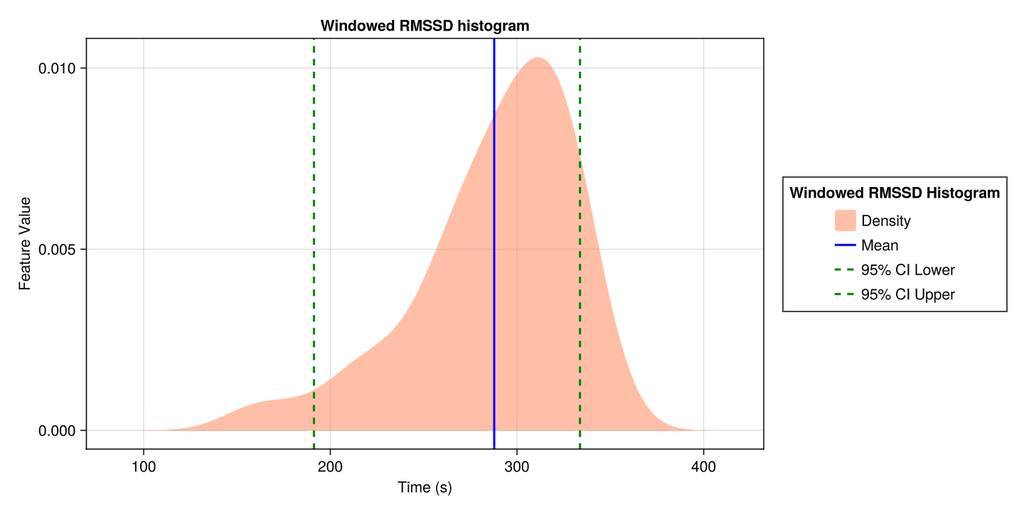

```julia
ds_windowed = HeartRateLab.Features.windowed_feature_set(
    data, features=["rmssd", "vlf"], window_size=60, stride=10
)
f = Figure(size=(600, 600));
ax = Axis(f[1, 1],
    title="Windowed RMSSD histogram",
    xlabel="Time (s)",
    ylabel="Feature Value",
)
x = ds_windowed.rmssd
# Confidence intervals
mean_x = mean(x)
std_x = std(x)
ci_lower = StatsBase.quantile(x, 0.025)
ci_upper = StatsBase.quantile(x, 0.975)
density!(ax, x, label="Density", color=(:coral, 0.5))
vlines!(ax, mean_x, color=:blue, linewidth=2, label="Mean")
vlines!(ax, ci_lower, color=:green, linewidth=2, linestyle=:dash, label="95% CI Lower")
vlines!(ax, ci_upper, color=:green, linewidth=2, linestyle=:dash, label="95% CI Upper")
# hist!(ax, x, bins=30, label="RMSSD")
f[1, 2] = Legend(f, ax, "Windowed RMSSD Histogram",
    position=:bottomright,
    title="Windowed RMSSD Histogram Legend",
    fontsize=10,
    bgcolor=:white,
    framecolor=:black)
f
```

## Dynamic Systems

- LIF
- VanDerPol
- Lorenz
- Dynamic Mode Decomposition
- Delayed Differential Analysis

[figure not shown]

Van der Pol Oscillator, By Ashraful - Own work using Matlab program., CC BY-SA 3.0, https://commons.wikimedia.org/w/index.php?curid=116710259

## Leaky Integrate-and-Fire Model (LIF)

[figure not shown]

Leaky Integrate and Fire time plot Gerstner et al. (2014)

```julia
using DifferentialEquations
using Random

# Parameters for the HRV model
params = (
    τ=0.6,        # Integration time constant
    I_base=1.1,   # Baseline input to the integrator
    threshold=0.9, # Firing threshold
    noise_amp=0.15,  # Amplitude of stochastic noise
)

# Define the integrate-and-fire dynamics
function hrv_dynamics(dV, V, p, t)
    dV[1] = (p.I_base - V[1]) / p.τ + p.noise_amp * randn()
end

# Time span for simulation
tspan = (0.0, 1000.0)  # Simulate for 100 seconds
V0 = [0.0]            # Initial integrator value

# Define the callback to reset the integrator and log spike times
function hrv_fire!(integrator)
    # Log the firing time
    global spike_times
    push!(spike_times, integrator.t)
    # Reset the integrator value
    integrator.u[1] = 0.0
end

# Condition for firing
function fire_condition(u, t, integrator)
    u[1] >= params.threshold
end

# Initialize a global spike time array
global spike_times = Float64[]

# Create a DiscreteCallback for firing events
fire_callback = DiscreteCallback(fire_condition, hrv_fire!)

# Solve the integrate-and-fire HRV model
hrv_problem = ODEProblem(hrv_dynamics, V0, tspan, params)
```

```
ODEProblem with uType Vector{Float64} and tType Float64. In-place: true
timespan: (0.0, 1000.0)
u0: 1-element Vector{Float64}:
 0.0
```

## Solving ODEs

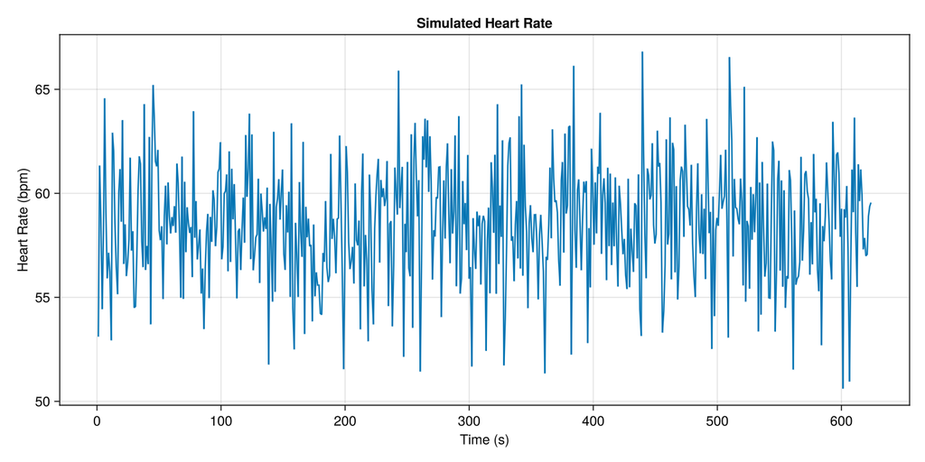

```julia
hrv_solution = solve(hrv_problem, Tsit5(); callback=fire_callback)

# Interbeat intervals (IBIs) in milliseconds
IBIs = diff(spike_times) * 1000.0
IBIs = HeartRateLab.replace_bio_outliers(IBIs)

# Plot the results
f = Figure(size=(1600, 800));
ax = Axis(f[1, 1],
    title="Simulated Heart Rate",
    xlabel="Time (s)",
    ylabel="Heart Rate (bpm)",
)
# stem!(ax, spike_times[1:(end - 1)], IBIs,
#     marker=:circle, color=:blue, markersize=5)
t = cumsum(IBIs) ./ 1000 # Convert to seconds
x = 60000 ./ IBIs # Convert to bpm
lines!(ax, t, x, label="Simulated Heart Rate")
f
```

## Bayesian Inference and Statistical Modeling

[figure not shown]

Pictorial proof of Bayes’ theorem By Cmglee - Own work, CC BY-SA 4.0, https://commons.wikimedia.org/w/index.php?curid=143581610

Parameter Estimation:

```
τ=0.6,        # Integration time constant
I_base=1.1,   # Baseline input to the integrator
threshold=0.9, # Firing threshold
noise_amp=0.15,  # Amplitude of stochastic noise
```

```julia
using Turing
using SequentialSamplingModels: LBA

# Generate synthetic data
Random.seed!(42)
dist = LBA(ν=[3.0], A=.8, k=.2, τ=.3)
n_trials = 100
data = rand(dist, n_trials)

@model function lba(data; min_rt=minimum(data.rt))
    ν ~ MvNormal(fill(2.0, 2), I * 3)
    A ~ truncated(Normal(0.8, 0.8), 0.0, Inf)
    k ~ truncated(Normal(0.2, 0.2), 0.0, Inf)
    τ ~ Uniform(0.0, min_rt)
    data ~ LBA(; ν, A, k, τ)
end

# # Run inference
chain = sample(lba(data), NUTS(), 50)

using StatsPlots
StatsPlots.plot(chain)
```

## Deep Learning

- Flux.jl
- Variational Autoencoders

[figure not shown]

A Variational Autoencoder

```julia
using Flux
using Statistics
using Random

# Set random seed for reproducibility
Random.seed!(42)

# Define the VAE model
struct VAE
    encoder
    decoder
    μ
    logσ
end

Flux.@functor VAE

function VAE(input_dim, latent_dim, hidden_dims)
    # Encoder (1D convolutional layers)
    encoder = Chain(
        Conv((3,), 1 => hidden_dims[1], relu; pad=(1,)),
        Conv((3,), hidden_dims[1] => hidden_dims[2], relu; pad=(1,)),
        Flux.flatten,
        Dense(hidden_dims[2] * input_dim, 64, relu),
    )

    # Latent space mean and log-variance
    μ = Dense(64, latent_dim)
    logσ = Dense(64, latent_dim)

    # Decoder (transposed 1D convolutional layers)
    decoder = Chain(
        Dense(latent_dim, 64, relu),
        Dense(64, hidden_dims[2] * input_dim, relu),
        x -> reshape(x, (input_dim, hidden_dims[2])),
        ConvTranspose((3,), hidden_dims[2] => hidden_dims[1], relu; pad=(1,)),
        ConvTranspose((3,), hidden_dims[1] => 1, sigmoid; pad=(1,)),
    )

    return VAE(encoder, decoder, μ, logσ)
end

# Reparameterization trick
function reparameterize(μ, logσ)
    σ = exp.(logσ)
    ϵ = randn(Float32, size(μ))
    return μ + σ .* ϵ
end

# VAE forward pass
function (vae::VAE)(x)
    h = vae.encoder(x)
    μ, logσ = vae.μ(h), vae.logσ(h)
    z = reparameterize(μ, logσ)
    # return vae.decoder(z), μ, logσ
    x_reconstructed = vae.decoder(z)
    # Reshape decoder output to match input shape for loss calculation
    return reshape(x_reconstructed, size(x)), μ, logσ
end

# Loss function (reconstruction + KL divergence)
function vae_loss(vae, x)
    x̂, μ, logσ = vae(x)
    reconstruction_loss = Flux.mse(x̂, x)
    kl_divergence = -0.5f0 * sum(1.0f0 .+ logσ .- μ .^ 2 .- exp.(logσ))
    return reconstruction_loss + kl_divergence
end

# Training loop
function train_vae(vae, data, epochs, batch_size, opt)
    train_loader = Flux.DataLoader(data; batchsize=batch_size, shuffle=true)
    for epoch in 1:epochs
        for x in train_loader
            loss, grads = Flux.withgradient(vae) do m
                vae_loss(m, reshape(x, (size(x, 1), 1, size(x, 2))))
            end
            Flux.update!(opt, vae, grads[1])
        end
        println("Epoch $epoch, Last batch loss: $(loss)")
    end
end

# Parameters
input_dim = 64  # Window size
latent_dim = 16  # Latent space dimension
hidden_dims = [32, 64]  # Encoder/decoder hidden dimensions
n_samples = 1000  # Number of samples
seq_length = input_dim  # Sequence length
batch_size = 32
epochs = 10

# Initialize VAE model
vae = VAE(input_dim, latent_dim, hidden_dims)

# Optimizer
opt = ADAM(0.001)

# Train the VAE
train_vae(vae, data, epochs, batch_size, opt)
```

## Visualization

All visualizations in this notebook can be generated live.

```julia
N = 10000
x = Observable(rand(N))
fig = Figure(size=(1800, 600));
ax = Axis(fig[1, 1], subtitle="Random Variable")
scatter!(ax, x)
ylims!(ax, -1, 2)
ax = Axis(fig[1, 2], subtitle="Distribution")
# density!(ax, x)
hist!(ax, x, bins=100)
xlims!(ax, -1, 2)
button = Button(fig[2, 1:2], label="New")
l = on(button.clicks) do b
    x[] = rand(N)
end
fig
```

**DEMO**

## Problem Solving with the HeartRateLab

What have we used the HeartRateLab for?

### Teaching and Learning

- Communication and Visualization
- Test-driven feature definition
- Ranges and normal values of features are part of our tests
- Open source encourages student engagement
- Material belongs to the students
- Students can run the code and see the results
- Online demos aid visual understanding

### Managing Expectations and Priors

- Open Data Sets become the basis for our Normative Datasets
- For every study, a graph of related studies can be selected from a superset to compare and contrast the results.
- Given similar studies, we can design experiments with quantified expectations (Bayesian priors).
- We can identify outliers in different populations, and under different conditions.

### Modeling and Predicting

- Models can be tested against normative datasets.
- Their accuracy and precision can be quantified.
- Artificial models encourage model-thinking: no true model, but useful models.
- The Dao that can be named is not the eternal Dao.

## What do we do with the HeartRateLab?

- Arousal and Relaxation
- Cognitive Mental Workload
- Attention and Dual-Tasking
- Attentional Networks
- Facial Expression Observation
- Ocular Rivalry and Concious Perception
- Cognitive Flexibility
- Heart Rate Variability Biofeedback
- Mindfulness and Contemplative Practices
- Neurodiversity, ADHD, and Autism

## Structured and Formal Management of Cognitive Tools and Resources.

## Tools and Resources

[figure not shown]

ResearchRabbit

[figure not shown]

The cynefin framework Snowden and Boone (2007)

- [OpenNeuro](https://openneuro.org/)
- [PhysioNet](https://physionet.org/)
- [Wikidata](https://www.wikidata.org/)
- [Academic Torrents](https://academictorrents.com/browse.php)
- [Kaggle](https://www.kaggle.com/)
- [Zenodo](https://zenodo.org/)
- [Open Science Framework](https://osf.io/)
- [**HeartRateLab**](https://github.com/abcsds/HeartRateLab.jl)
- [**SequentialSamplingModels**](https://github.com/dfisher/SequentialSamplingModels.jl)
- [**MNE**](https://mne.tools/stable/auto_tutorials/index.html)
- [**LabStreamingLayer (LSL)**](https://labstreaminglayer.readthedocs.io/index.html)

## Analysis

- [**JASP**](https://jasp-stats.org/)
- [JAMOVI](https://www.jamovi.org/)
- [R](https://www.r-project.org/)
- [R Studio](https://rstudio.com/)
- [Julia](https://julialang.org/)
- [Python](https://www.python.org/)
- [SPSS](https://www.ibm.com/analytics/spss-statistics-software)
- [NotebookLM](https://notebooklm.com/)
- [Ollama](https://ollama.com/)
- [LangChain](https://python.langchain.com/)
- [OpenWebUI](https://openwebui.org/)
- [Hugging Face](https://huggingface.co/)
- [Obsidian](https://obsidian.md/)
- [ResearchRabbit](https://www.researchrabbit.ai/)
- [Elicit](https://elicit.org/)
- [Consensus](https://consensus.app/)
- [Python Scholarly](https://pypi.org/project/scholarly/)
- [PyBibliometrics](https://pypi.org/project/pybibliometrics/)
- [Python SemanticScholar](https://pypi.org/project/semanticscholar/)
- [Padron del SNII](https://conahcyt.mx/sistema-nacional-de-investigadores/padron-de-beneficiarios/)

## References

Acar, Burak, Irina Savelieva, Harry Hemingway, and Marek Malik. 2000. “Automatic Ectopic Beat Elimination in Short-Term Heart Rate Variability Measurement.” *Computer Methods and Programs in Biomedicine* 63 (2): 123–31.

Gerstner, Wulfram, Werner M Kistler, Richard Naud, and Liam Paninski. 2014. *Neuronal Dynamics: From Single Neurons to Networks and Models of Cognition*. Cambridge University Press.

Kamath, MV, and EL Fallen. 1995. “Correction of the Heart Rate Variability Signal for Ectopics and Missing Beats’ Heart Rate Variability. Malik m, Camm AJ, Eds.” Boston: Blackwell Publishing.

Karlsson, Marcus, Rolf Hörnsten, Annika Rydberg, and Urban Wiklund. 2012. “Automatic Filtering of Outliers in RR Intervals Before Analysis of Heart Rate Variability in Holter Recordings: A Comparison with Carefully Edited Data.” *Biomedical Engineering Online* 11: 1–12.

MacDonald, Eilidh A, Robert A Rose, and T Alexander Quinn. 2020. “Neurohumoral Control of Sinoatrial Node Activity and Heart Rate: Insight from Experimental Models and Findings from Humans.” *Frontiers in Physiology* 11: 170.

Malik, Marek. 1996. “Heart Rate Variability: Standards of Measurement, Physiological Interpretation, and Clinical Use: Task Force of the European Society of Cardiology and the North American Society for Pacing and Electrophysiology.” *Annals of Noninvasive Electrocardiology* 1 (2): 151–81.

Netter, F. H., and Ciba Pharmaceutical Products. 1972. *The Ciba Collection of Medical Illustrations: Anatomy, Physiology, and Metabolic Disorders*. Nervous System. Ciba Pharmaceutical Products. https://books.google.at/books?id=2qARAQAAMAAJ.

Snowden, David J, and Mary E Boone. 2007. “A Leader’s Framework for Decision Making.” *Harvard Business Review* 85 (11): 68.